# WeRateDogs Insights & Visualization

## Number of retweets over years

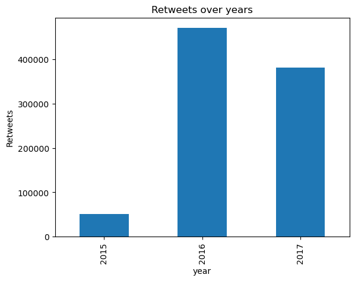

The `@dog_rates` retweets had drastically increased from 51560 retweet in 2015 to 470345 retweet in 2016. Then it shows a decrease to 380624 retweet in 2017

## The most retweeted dog breed each year

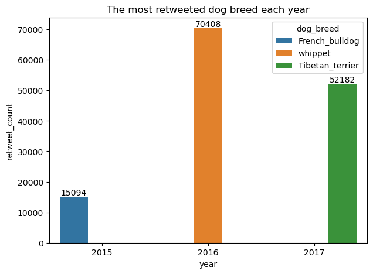

The above plot represents the most retweeted dog breed for each year, In 2015 we have French bulldog with 15094 retweet, Moving to 2016 we find in the top of the list Whippet breed, And finally we have Tibetan terrier in 2017

## The most lovable names

The most commonly traded names are charlie (11 dogs), Cooper (10 dogs), Lucy (10 dogs) and Oliver (10 dogs)

## Users' favorite dog stages

The most high rated dog stage is puppo with 12.18 mean rate. We can conclude that people tend to like more dogs in puppo stage

## Ratings Distribution

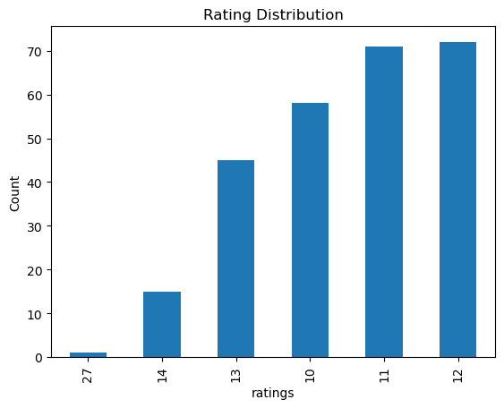

We notice from the rating distribution plot thet most dogs are rated from 11 to 12 ignoring 27 which considered as an outlier

## Dog stages

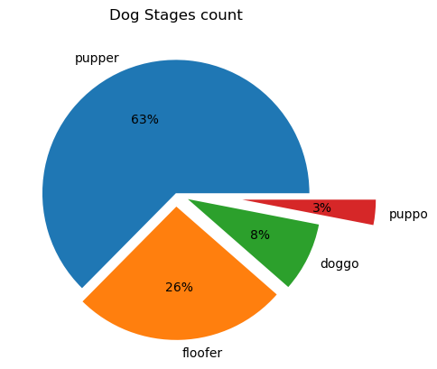

As we can see in this pie chart most posted dogs are in the pupper stage with 63%, then comes the floofer stage with 26%. People tend to own dogs in pupper and floofer stages more than doggo and puppo

**Knowing that puppo and doggo stages are representing a tiny part from the pie chart, they recieved the highest ratings from the users**